# a1

Aldwin Chong

2025-07-27

# ETO5513 - ASSIGNMENT 1

Aldwin Chong

### PROBLEM OUTLINE

As we continue to advance as a society and our economic output continues to grow, the world must now consider the future of the planet; namely can we continue economic output without the same destruction of the environment. In order to investigate this the question needs to be asked, which region is able to efficiently maintain economic output and what insights can be gleamed from this. That is, which region has the highest economic output whilst keeping CO2 emissions low?

### VARIABLE DESCRIPTION

The dataset includes the following variables (however most offer no value):

Dataset variable names

| var_name |
| --- |
| Entity |
| Code |
| Year |
| Annual.CO..emissions..per.capita. |
| GDP.per.capita |
| X900793.annotations |
| Population..historical. |
| World.regions.according.to.OWID |
| time |
| time.1 |
| time.2 |
| time.3 |

The data used in this mini-project was obtained via the 2022 figures from [Our World in Data](https://ourworldindata.org/grapher/co2-emissions-vs-gdp).

```
## The dataset contains 164 observations and 12 variables.
```

```
## 'data.frame':    2 obs. of  12 variables:
##  $ Entity                           : chr  "Afghanistan" "Albania"
##  $ Code                             : chr  "AFG" "ALB"
##  $ Year                             : int  2022 2022
##  $ Annual.CO..emissions..per.capita.: num  0.26 1.83
##  $ GDP.per.capita                   : num  1358 12978
##  $ X900793.annotations              : logi  NA NA
##  $ Population..historical.          : int  40578801 2827562
##  $ World.regions.according.to.OWID  : chr  "Asia" "Europe"
##  $ time                             : int  2022 2022
##  $ time.1                           : int  2023 2023
##  $ time.2                           : int  2022 2022
##  $ time.3                           : int  2022 2022
```

However to make the dataframe more easier to read and reference we can remove the unnecessary variables and rename the variables to more applicable titles. As mentioned above, “Year”, “time”, time.1”, “time.2”, “time.3” and “X900793.annotations” are all not needed and can be removed. The other variables can be renamed to more easily understandable labels: country = ‘Entity’, iso_code = ‘Code’, co2_per_capita = ‘Annual.CO..emissions..per.capita.’, gdp_per_capita = ‘GDP.per.capita’, population = ‘Population..historical.’, region = ‘World.regions.according.to.OWID’

From here we can then calculate some summary statistics to see the CO2 emissions and GDP production per region.

Summary Statistics by Region

| region | mean_co2 | var_co2 | med_co2 | mean_gdp | var_gdp | med_gdp |
| --- | --- | --- | --- | --- | --- | --- |
| Africa | 1.19 | 2.82 | 0.44 | 5728.81 | 42311609 | 2934.77 |
| Asia | 6.82 | 62.48 | 3.58 | 24283.93 | 798884637 | 13442.91 |
| Europe | 5.84 | 5.38 | 5.65 | 33756.35 | 261413253 | 31885.45 |
| North America | 4.81 | 43.21 | 2.51 | 16342.06 | 226872525 | 10452.17 |
| Oceania | 10.41 | 36.21 | 10.41 | 45149.78 | 95210478 | 45149.78 |
| South America | 2.53 | 1.18 | 2.29 | 13372.24 | 34055853 | 13615.97 |

As we can see from the above summary statistics, Oceania has the highest mean CO2 emissions and GDP per capita, whilst Africa has the lowest values for both. **The regions of North America, Asia and Oceania have the highest variation if CO2 emissions per capita indicating that countries within these regions have vastly different energy cosumption and composition profiles.**

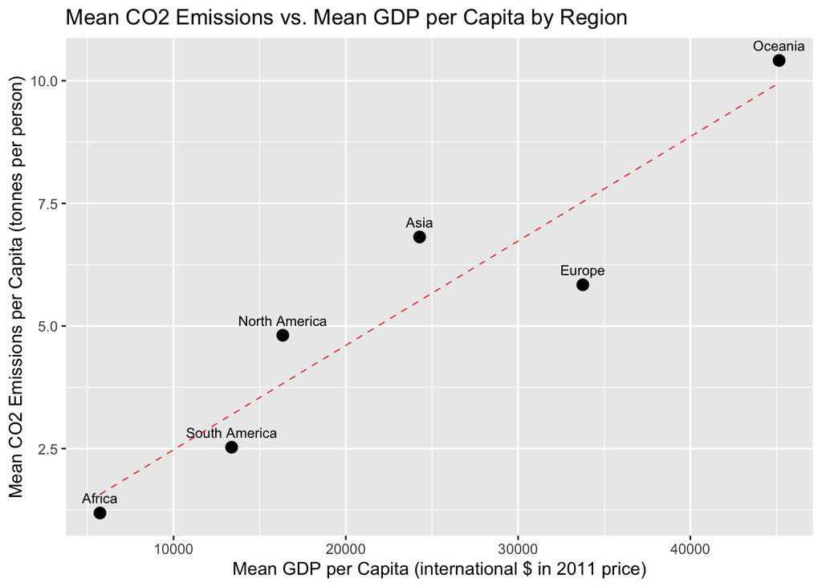